# Лабораторная работа №9

Операционные системы

Гасанова Ш. Ч.

Российский университет дружбы народов, Москва, Россия

8 апреля 2025

## Цель

Освоение основных возможностей командной оболочки Midnight Commander. Приобретение навыков практической работы по просмотру каталогов и файлов; манипуляций с ними.

## Задание

1. Изучить информацию о mc, вызвав в командной строке man mc.
2. Запустить из командной строки mc, изучите его структуру и меню.
3. Выполнить несколько операций в mc, используя управляющие клавиши.
4. Выполните основные команды меню левой (или правой) панели.
5. Используя возможности подменю Файл
   - просмотреть содержимое текстового файла;
   - редактировать содержимое текстового файла (без сохранения результатов редактирования);
   - создать каталог;
   - копировать файлы в созданный каталог.
6. С помощью соответствующих средств подменю Команда
   - сделать поиск в файловой системе файла с заданными условиями;
   - выборать и повторить одной из предыдущих команд;
   - перейти в домашний каталог;
   - проанализировать файл меню и файл расширений.

## Задание

7. Вызвать подменю Настройки. Освоить операции, определяющие структуру экрана mc.
8. Создать текстовой файл text.txt, открыть с помощью mc.
9. Вставить в файл небольшой фрагмент текста, скопированный из любого источника.
10. Проделайте с текстом следующие манипуляции, используя горячие клавиши:
    - Удалить строку текста.
    - Выделить фрагмент текста и скопировать на новую строку.
    - Выделить фрагмент текста и перенести его на новую строку.
    - Сохранить файл.
    - Отменить последнее действие.
    - Перейти в конец файла и написать некоторый текст.
    - Перейти в начало файла и написать некоторый текст.
    - Сохранить и закрыть файл.
11. Открыть файл с исходным текстом на некотором языке программирования (например C или Java)
12. Используя меню редактора, включить подсветку синтаксиса, если она не включена, или выключить, если она включена.

## Выполнение лабораторной работы

Изучаю информацию о mc, вызвав в командной строке man mc

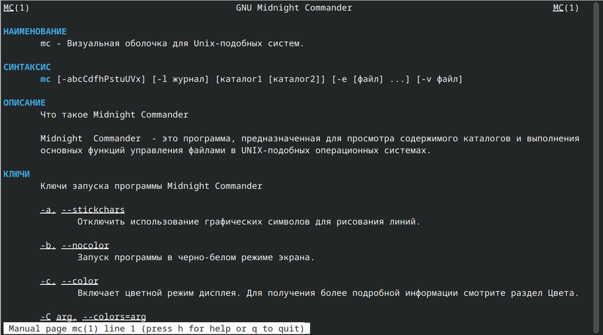

Man mc

## Выполнение лабораторной работы

Запустить из командной строки mc, выполняю несколько операций в mc, используя управляющие клавиши

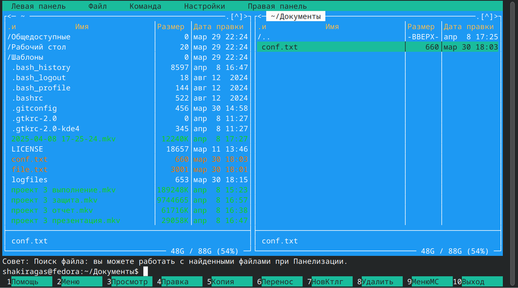

Копирование файла

## Выполнение лабораторной работы

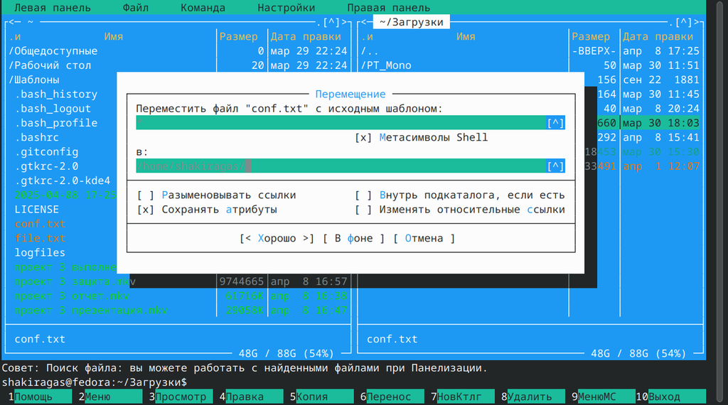

Перемещение файла

## Выполнение лабораторной работы

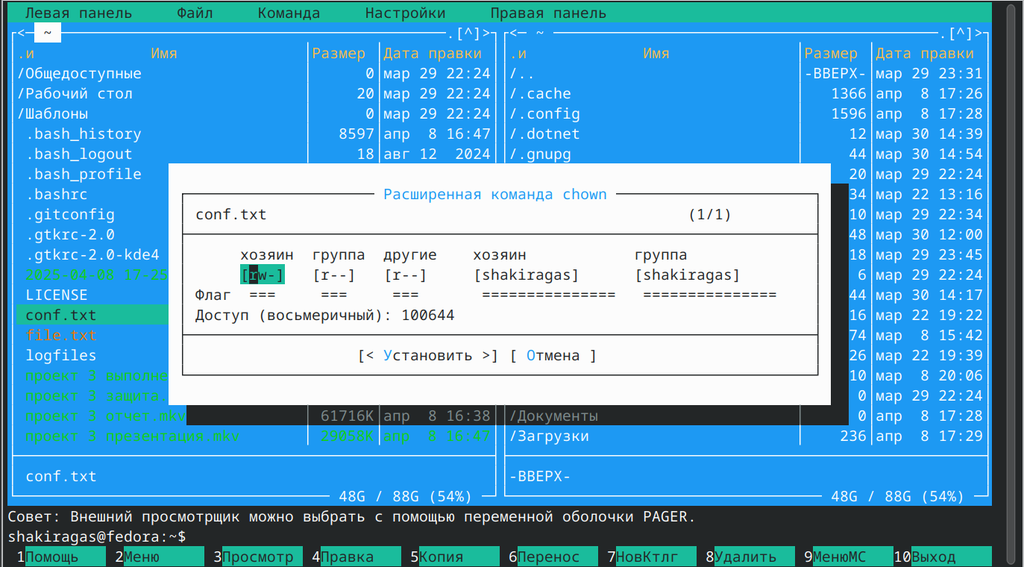

Просмотр прав

## Выполнение лабораторной работы

Выполняю некоторые команды меню левой панели

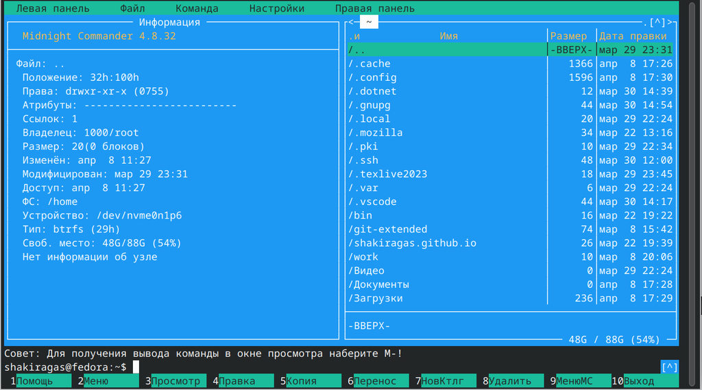

Информация файла

## Выполнение лабораторной работы

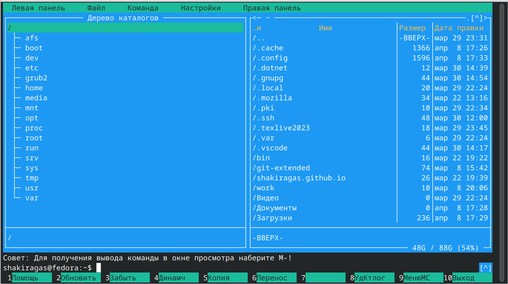

Дерево

## Выполнение лабораторной работы

Просматриваю содержимое текстового файла

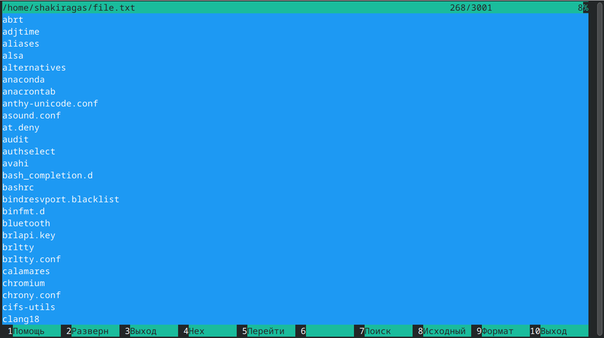

Содержимое файла

## Выполнение лабораторной работы

Редактирую содержимое текстового файла

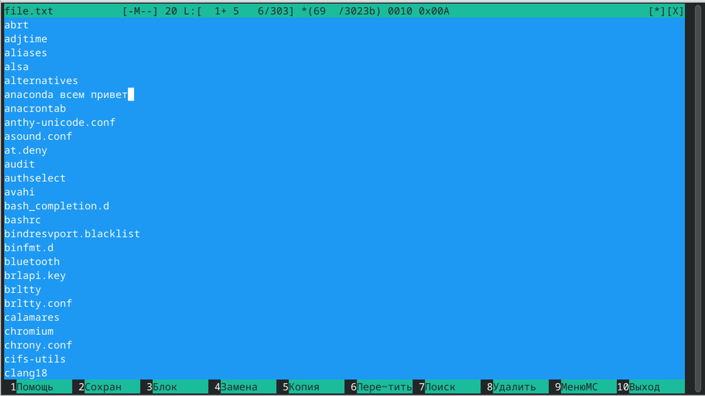

Редактирование файла

## Выполнение лабораторной работы

Создаю каталог

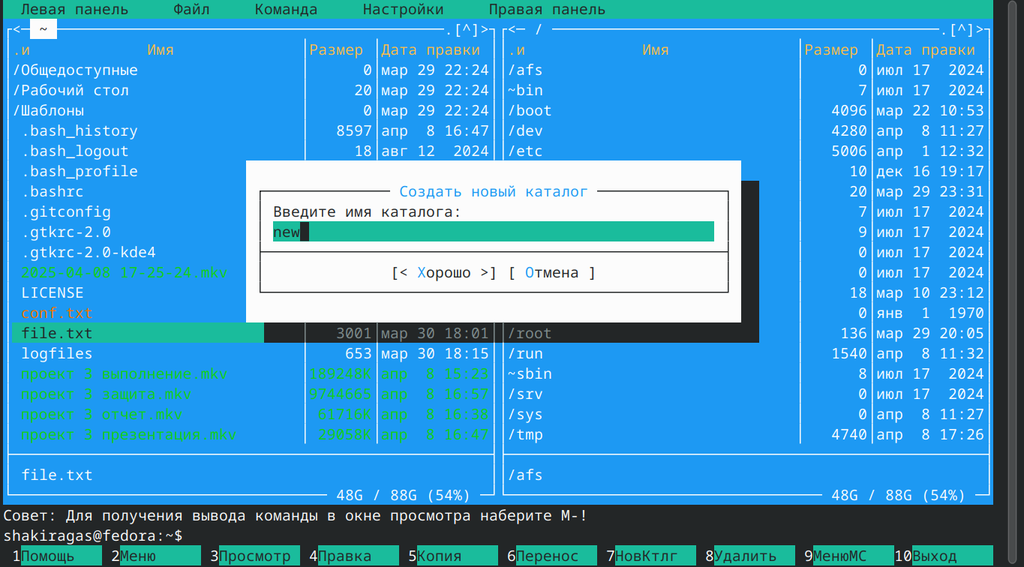

Создание каталога

## Выполнение лабораторной работы

Копирую файл в созданный каталог

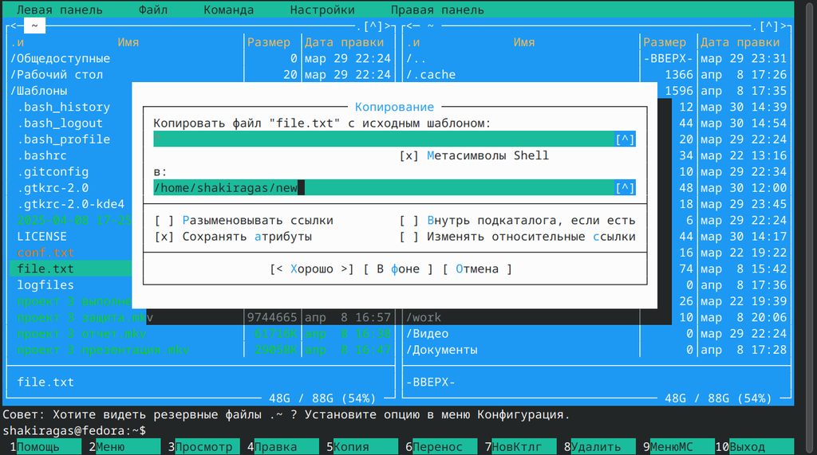

Копирование файла

## Выполнение лабораторной работы

Делаю поиск в файловой системе файла с заданными условиями

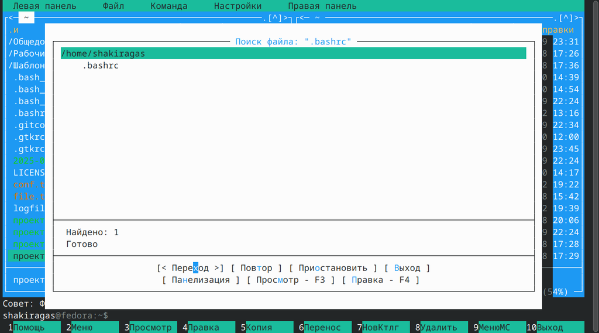

Поиск файла

## Выполнение лабораторной работы

Выбираю и повторяю одной из предыдущих команд

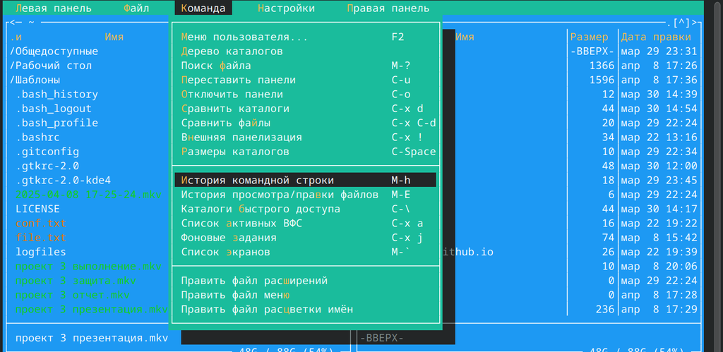

Повторение предыдущих команд

## Выполнение лабораторной работы

Анализирую файл меню и файл расширений

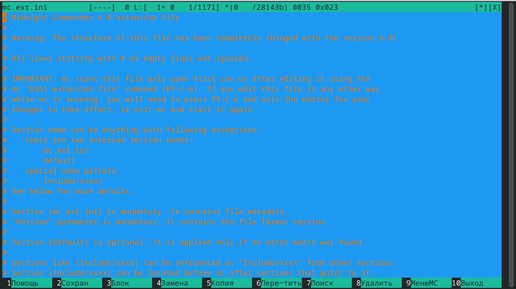

## Выполнение лабораторной работы

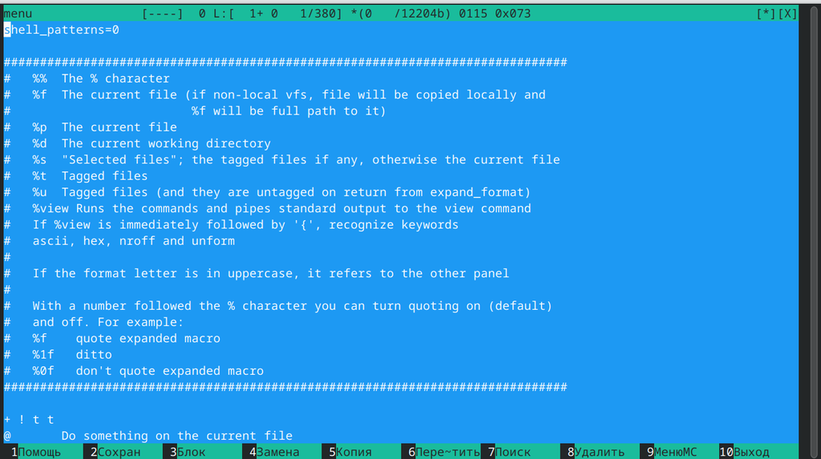

## Выполнение лабораторной работы

Вызываю подменю Настройки. Меняю внешний вид экрана mc

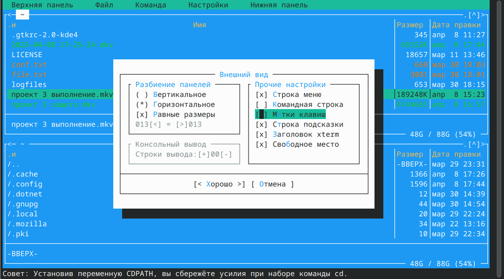

Внешний вид

## Выполнение лабораторной работы

Создаю файл text.txt, вставляю туда произвольный текст

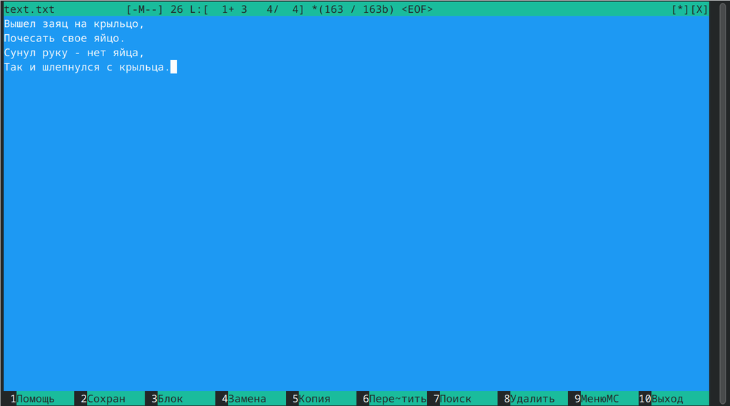

Новый текстовый файл

## Выполнение лабораторной работы

С помощью горячих клавиш удаляю строку текста

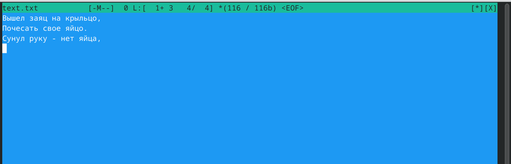

Удаление строки

## Выполнение лабораторной работы

Выделяю фрагмент текста и копирую на новую строку

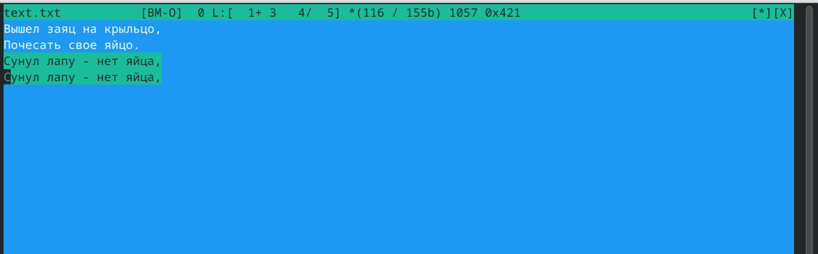

Копирование фрагмента на новую строку

## Выполнение лабораторной работы

Выделяю фрагмент текста и переношу его на новую строку

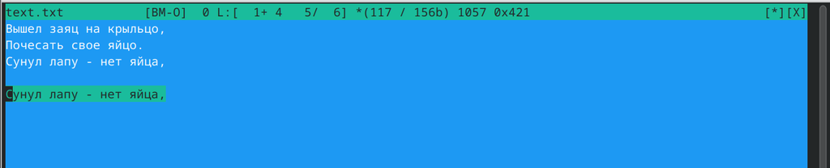

Перемещение фрагмента на новую строку

## Выполнение лабораторной работы

Сохраняю файл

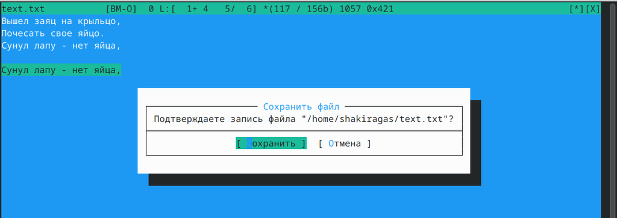

Сохранение

## Выполнение лабораторной работы

Отменяю последнее действие

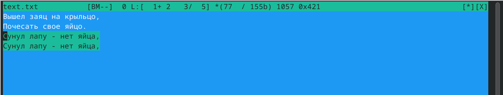

Отмена последнего действия

## Выполнение лабораторной работы

Перехожу в конец файла и пишу текст

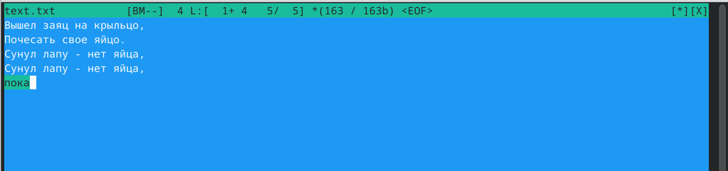

Текст в конце файла

## Выполнение лабораторной работы

Перехожу в начало файла и пишу текст

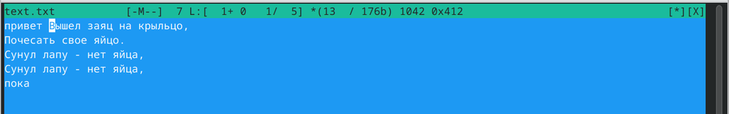

Текст в начале файла

## Выполнение лабораторной работы

Сохраню и заурываю файл

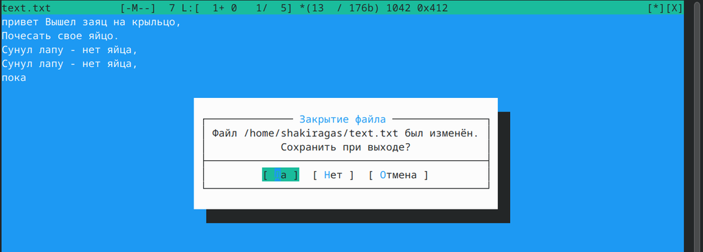

Сохранение

## Выполнение лабораторной работы

Используя меню редактора, выключаю подсветку синтаксиса

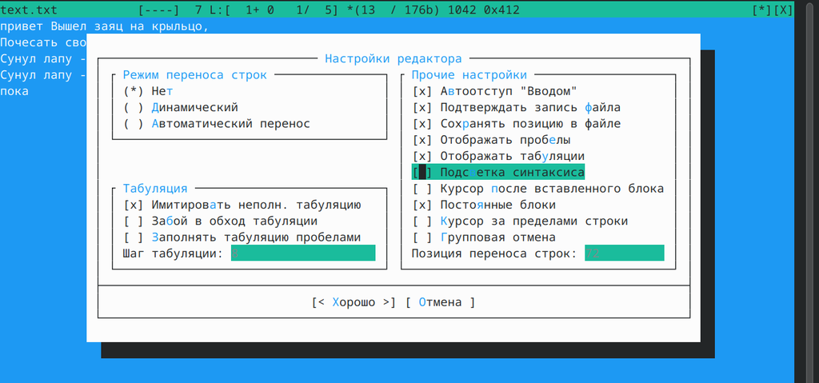

Подсветка синтаксиса

## Выводы

При выполнении данной лабораторной работы я освоила основные возможностей командной оболочки Midnight Commander. Приобрела навыки практической работы по просмотру каталогов и файлов; манипуляций с ними.

## Список литературы

1. Лабораторная работа №9 [Электронный ресурс]